# Electricity Demand

The CSV data files (above) contain daily electricity demand data for an office building in New York City – one contains data for the 5-year period 2011-2015 and the other for 2016. To successfully complete this assignment, you will:

Read the 2011-2015 CSV file into the RStudio environment, then generate summary statistics and a time series chart.

-First use prophet package to create a model for the 2011-2015 data, breaking out the seasonality of the data and the actual trend in demand. Determine the level of seasonality based upon what you have learned about electricity demand data in a climate like that of New York City. Generate charts for the raw data, seasonality and trend.

- Use the prophet package to forecast data for 2016; store the data in a data frame for subsequent analysis.
- Then use the stR package to repeat what was done with the prophet package in Step 2.
- Use the forecast package to forecast 2016 data, taking care to choose the most appropriate forecasting method for this type of data; add the forecasted data to the to the data frame you created in Step 3.
- Use at least three different statistical metrics to compare the two forecasted datasets to the actual 2016 data (contained in the 2016 CSV file) and determine which package (prophet or stR) was best at forecasting 2016 data (i.e., which dataset more closely matched the actual 2016 data when looking at the results of the three statistical tests).

```r
require(ggplot2)
require(prophet)
require(forecast)
require(stR)
# load and change to date format
f = file.path('data','daily_demand_11-15.csv')
elec_demand_2011_2015 = read.csv(f, stringsAsFactors = F)
f = file.path('data', 'daily_demand_16.csv')
elec_demand_2016 = read.csv(f, stringsAsFactors = F)
rm(f)

elec_demand_2011_2015$ds = as.Date.character(elec_demand_2011_2015$ds, '%m/%d/%Y')
elec_demand_2016$ds = as.Date.character(elec_demand_2016$ds, '%m/%d/%Y')
```

### Summary Statistics and Time Series 2011-2015

```r
summary(elec_demand_2011_2015$y)
```

```
##    Min. 1st Qu.  Median    Mean 3rd Qu.    Max.    NA's
##   59.43  444.06  499.84  547.65  603.16 1141.09      33
```

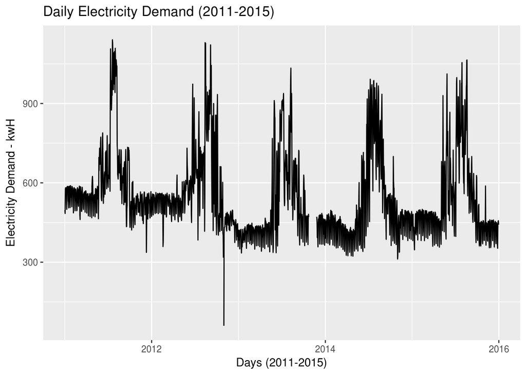

```r
ggplot(data = elec_demand_2011_2015, aes(x=ds, y=y)) +
    geom_line() +
    xlab('Days (2011-2015)') +
    ylab('Electricity Demand - kwH') +
    ggtitle('Daily Electricity Demand (2011-2015)')
```

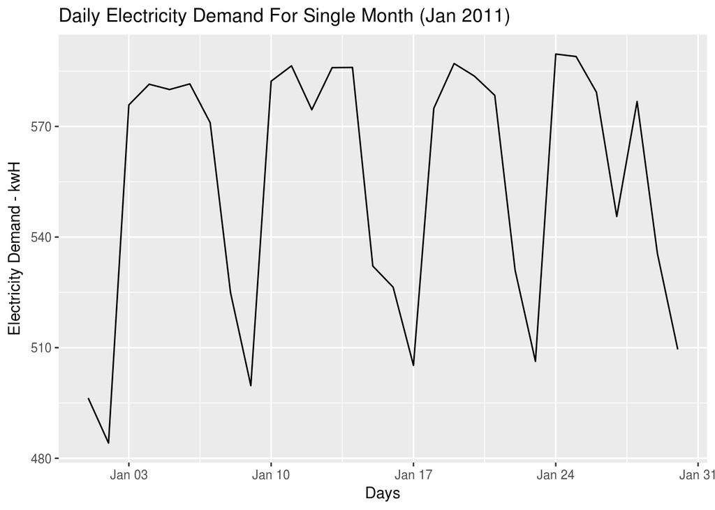

```r
ggplot(data = elec_demand_2011_2015[1:30,], aes(x=ds, y=y)) +
    geom_line() +
    xlab('Days') +
    ylab('Electricity Demand - kwH') +
    ggtitle('Daily Electricity Demand For Single Month (Jan 2011)')
```

The summary statistics show an overall mean value of 547.65 kwH electricity demand. There are 33 missing data points as seen in the summary as well as the gap in the time series chart. These missing values will have to be removed for the forecast package.

The time series plots show that there is periodicity on both the weekly and yearly levels. This is due to a reduction in electricity demand on weekends and an increase in electricity demand during summer months.

### Prediction using Prophet Package

The prophet package is used to predict 365 days given yearly and weekly seasonality in the data.

```r
mod = prophet(elec_demand_2011_2015, yearly.seasonality = T, weekly.seasonality = T)
```

```
## Disabling daily seasonality. Run prophet with daily.seasonality=TRUE to override this.
```

```
## Initial log joint probability = -22.4069
## Optimization terminated normally:
##   Convergence detected: relative gradient magnitude is below tolerance
```

```r
f = make_future_dataframe(mod,periods=365)
future = predict(mod, f)
```

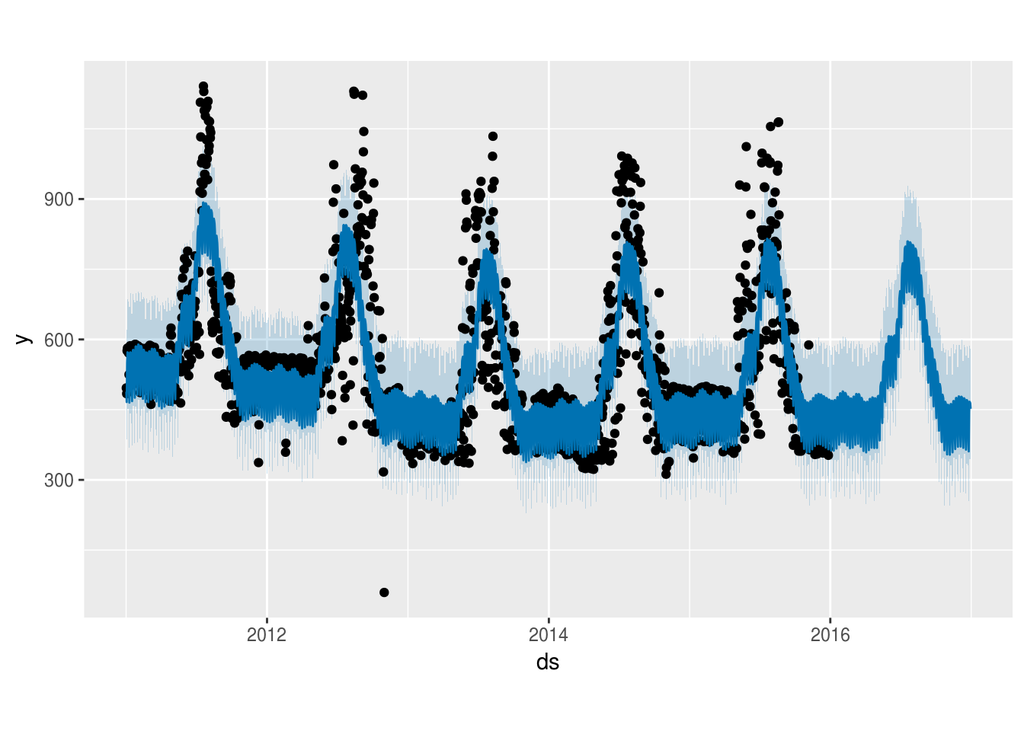

```r
plot(mod, future)
```

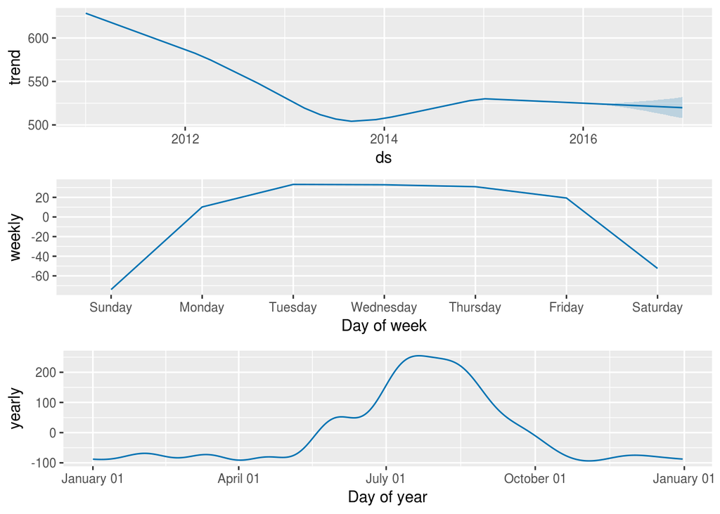

```r
prophet_plot_components(mod, future)
```

### stR package for STR decomposition

A similar decomposition is used with the stR package. The seasonal demand values are converted to a multi-seasonal time series

```r
t = msts(elec_demand_2011_2015$y,seasonal.periods = c(7, 365.25), start=c(2011,1)) # convert to a multi-time-series with weekly and yearly seasonality
```

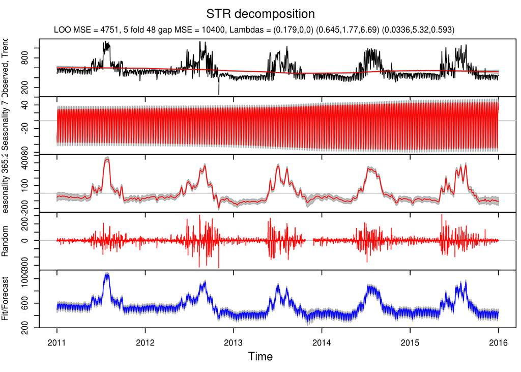

```r
#fit = AutoSTR(t, gapCV=48,confidence=0.95)
#saveRDS(fit,'auto_str_fit.rds')
fit = readRDS('auto_str_fit.rds')

plot(fit)
```

The AutoSTR decomposition shows a similiar shaped trend to the prophet result. One additional feature that AutoSTR conveniently shows in the amount of noise in the signal. One can see that the summer months are much more volatile and show a much higher degree of unpredictability than the winter months.

#### Using forecast

Both snaive and auto.arima methods were used to forecast 2016 data. Note that D=1 must be set in auto.arima in order for it to be able to detect the seasonality in the time series object.

```r
#aarima_model = auto.arima(t, D=1)
#saveRDS(aarima_model,'aarima_model.RDS')
#aarima_model = readRDS('aarima_model.RDS')
#f_arima = forecast(aarima_model, h=365)
#saveRDS(f_arima,'f_arima.rds')

f_arima = readRDS('f_arima.rds')
```

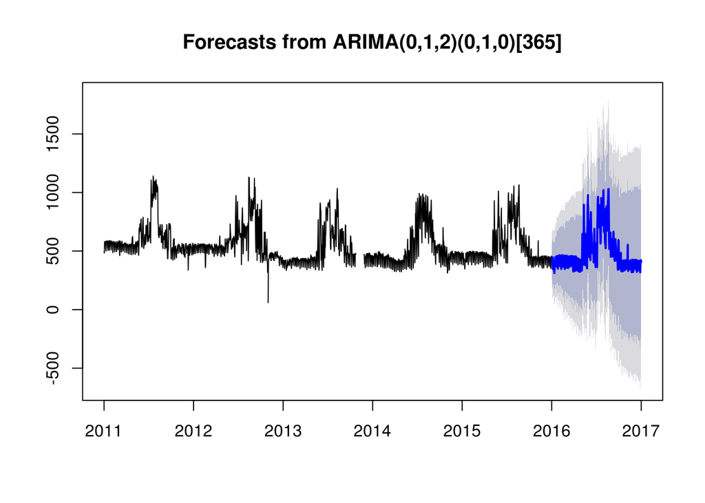

```r
plot(f_arima)
```

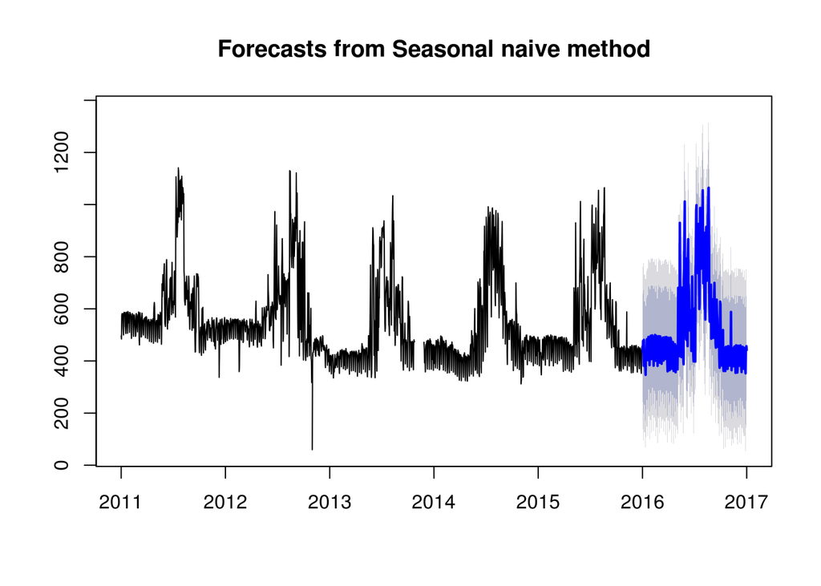

```r
#snaive_fmodel = snaive(t, h=365)
#saveRDS(snaive_fmodel, 'snaive_model.rds')
snaive_fmodel = readRDS('snaive_model.rds')
plot(snaive_fmodel)
```

Both of these models show a similar result in the prediction. Both appear to overfit some of the variability in the summer months.

### Comparison with actual 2016 dataset

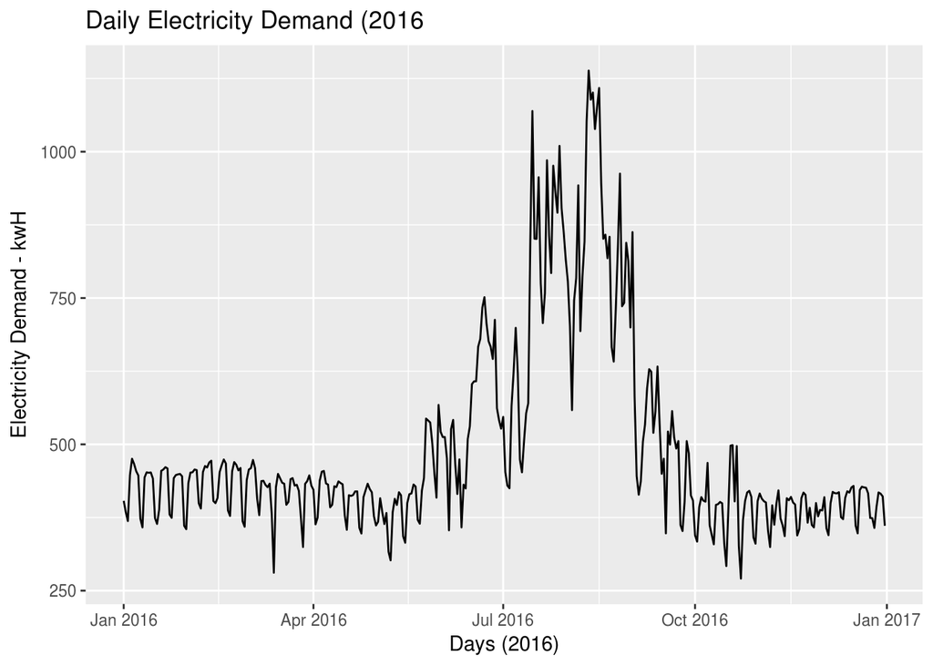

```r
ggplot(data = elec_demand_2016, aes(x=ds, y=y)) +
    geom_line() +
    xlab('Days (2016)') +
    ylab('Electricity Demand - kwH') +
    ggtitle('Daily Electricity Demand (2016')
```

```r
require(reshape2)
```

```r
s = snaive_fmodel$mean
aa = f_arima$mean

proph_ds_slice = data.frame(as.Date(future$ds), future$yhat)
colnames(proph_ds_slice) = c('ds','proph_mean')

elec = merge(elec_demand_2016, proph_ds_slice, by='ds',all.x=T)[-length(elec_demand_2016),]
elec$aa_mean = as.numeric(aa)
elec$snaive_mean = as.numeric(s)

colnames(elec)[2] = 'actual'
# melt for graph
elec_melt = melt(elec,id='ds', variable.name='demand')

plot_compare = function(demand_var_name){
    ggplot(data=elec_melt[(elec_melt$demand=='actual') | (elec_melt$demand==demand_var_name),],
       aes(x=ds, y=value, colour=demand)) +
     geom_line()
}
```

### plot comparisons of means from the three models

**Comparison of prophet yhat value after using predict() with actual 2016 demand**

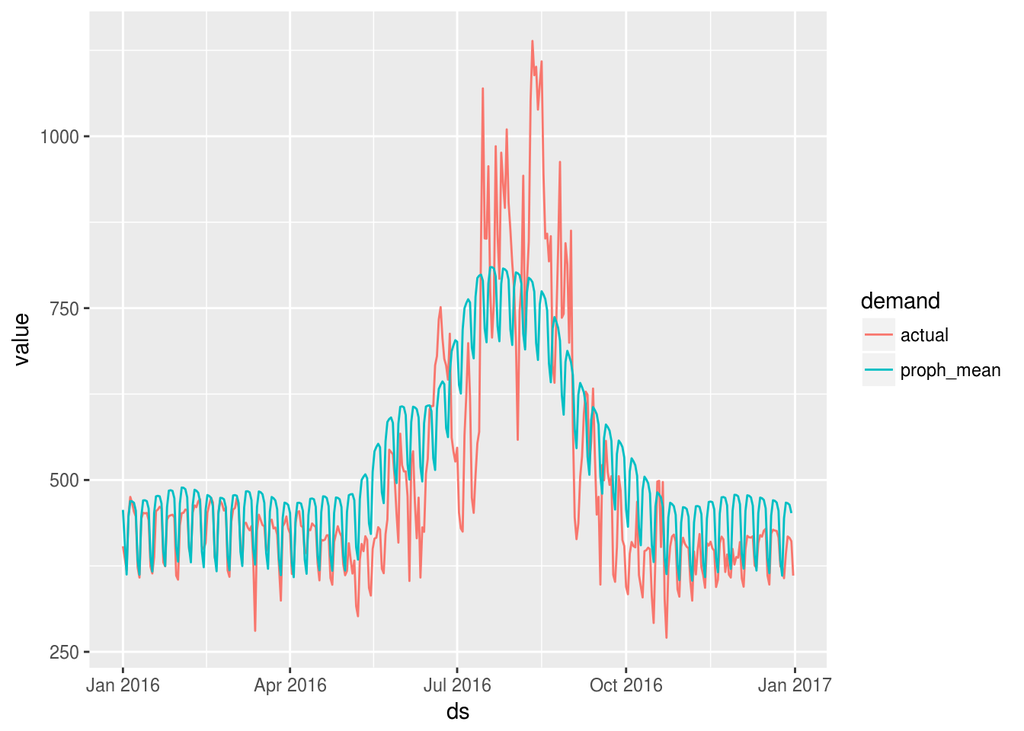

```r
plot_compare('proph_mean')
```

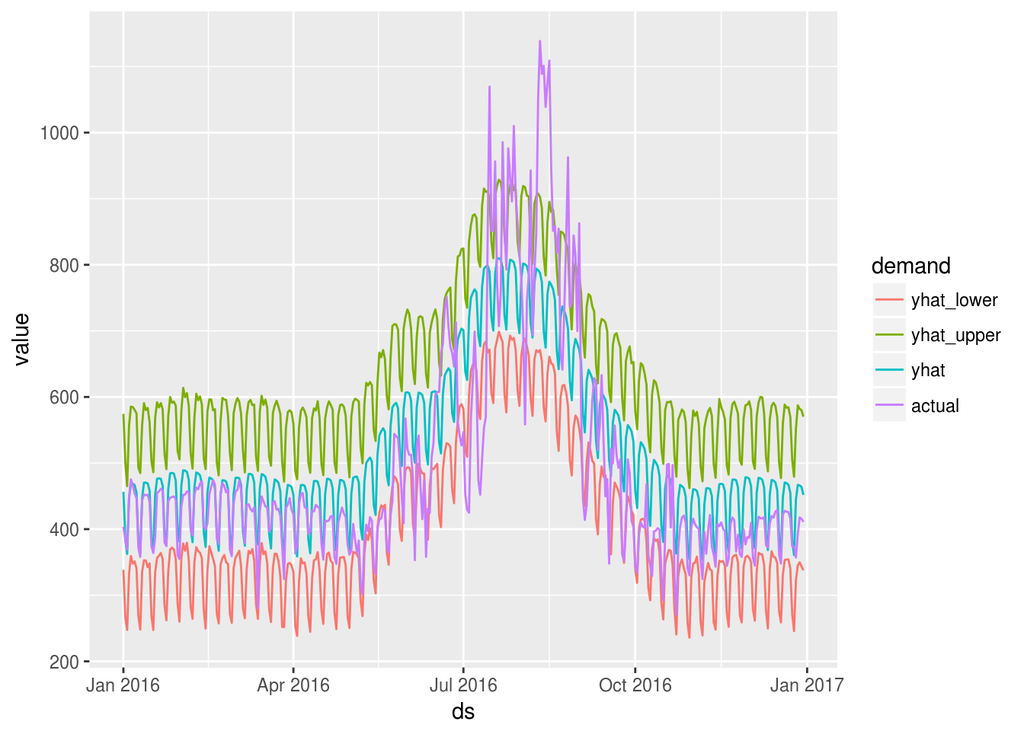

```r
future_2016 = future[as.Date(future$ds) >= as.Date('2016-01-01'),]

future_2016_yhats = data.frame(as.Date(future_2016$ds),future_2016$yhat_lower, future_2016$yhat_upper,future_2016$yhat)
colnames(future_2016_yhats) = c('ds','yhat_lower','yhat_upper', 'yhat')
proph_yhat_actual = merge(future_2016_yhats, elec_demand_2016, by='ds',all.x=T)
colnames(proph_yhat_actual)[5] = 'actual'

ggplot(data=melt(proph_yhat_actual,id='ds', variable.name='demand'),aes(x=ds, y=value, colour=demand)) + geom_line()
```

**Comparison of snaive mean value using forecast with acutal 2016 demand**

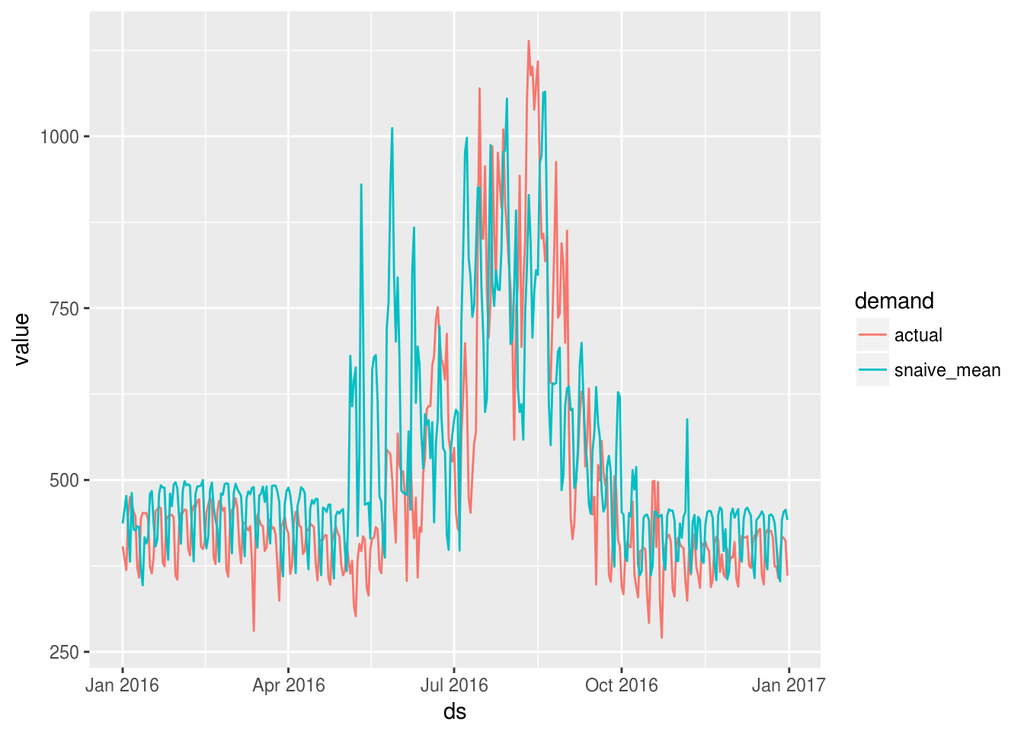

```r
plot_compare('snaive_mean')
```

**Comparison of auto.arima mean value using forecast with actual 2016 demand**

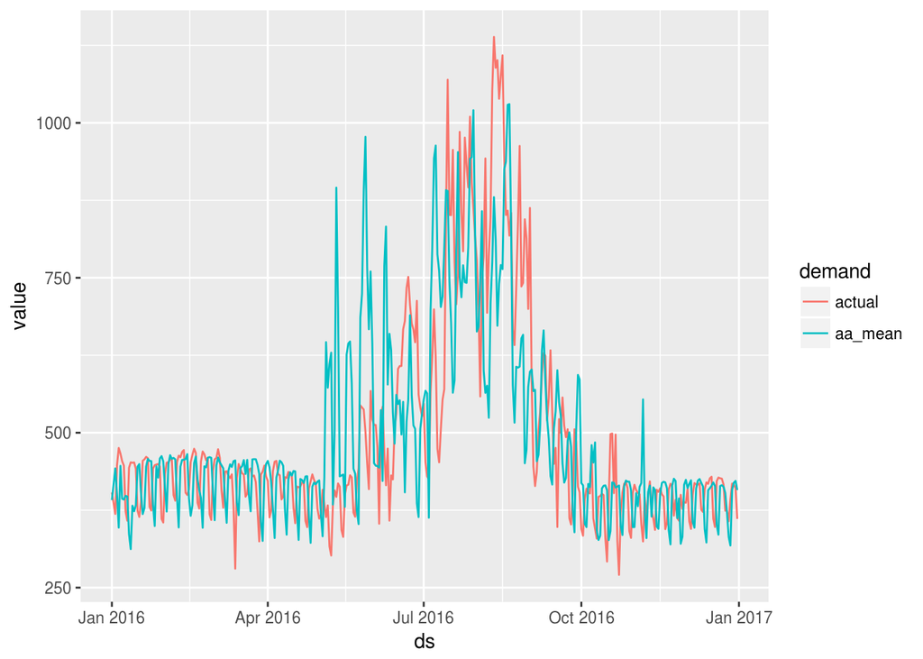

```r
plot_compare('aa_mean')
```

The auto.arima and snaive are almost identical in their overall shape. The predictions from both do not seem to capture the mean trend of the summer months as clearly the prophet package. Too much of the volatility in previous summer months were taken into account from May through September.

### Analysis of actual vs. predicted results

We can assess the accuracy using correlation tests and statistical measurements derived from simple linear regression by plotting the relationaship between the predicted values against the actual demand. In general positively correlated results are an indication that the predicted model is accurate.

**Acutal demand vs. prophet**

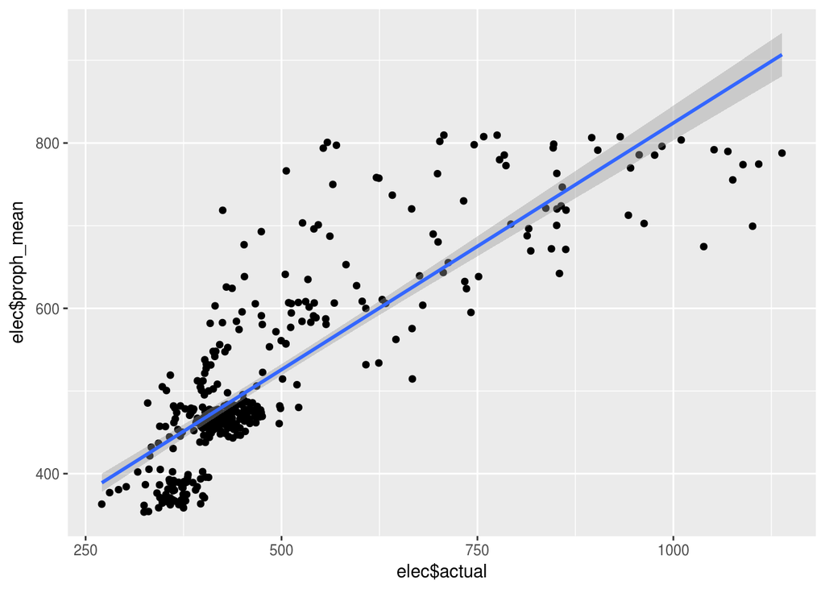

```r
ggplot(data=elec, aes(x=elec$actual,y=elec$proph_mean)) +
    geom_point() +
    geom_smooth(method='lm')
```

A look at the scatter plot with an lm regression line shows a postiive correlation between the data.

```r
cor.test(elec$actual, elec$proph_mean, method = "pearson", conf.level = 0.95)
```

```
##
##  Pearson's product-moment correlation
##
## data:  elec$actual and elec$proph_mean
## t = 29.816, df = 362, p-value < 2.2e-16
## alternative hypothesis: true correlation is not equal to 0
## 95 percent confidence interval:
##  0.8104249 0.8703637
## sample estimates:
##       cor
## 0.8429912
```

A Pearson correlation test at 0.95 CI shows an R value of 0.84 and statistically significant p-value. This means that the data is highly-correlated.

```r
summary(lm(actual~ proph_mean,data=elec))
```

```
##
## Call:
## lm(formula = actual ~ proph_mean, data = elec)
##
## Residuals:
##     Min      1Q  Median      3Q     Max
## -303.17  -42.99   -0.47   38.37  395.96
##
## Coefficients:
##               Estimate Std. Error t value Pr(>|t|)
## (Intercept) -127.65769   21.43853  -5.955 6.17e-09 ***
## proph_mean     1.19085    0.03994  29.816  < 2e-16 ***
## ---
## Signif. codes:  0 '***' 0.001 '**' 0.01 '*' 0.05 '.' 0.1 ' ' 1
##
## Residual standard error: 92.39 on 362 degrees of freedom
##   (1 observation deleted due to missingness)
## Multiple R-squared:  0.7106, Adjusted R-squared:  0.7098
## F-statistic:   889 on 1 and 362 DF,  p-value: < 2.2e-16
```

The actual linear regression summary gives decently accurate model with a high adjusted R2 value with a statistically significant p-value. The F-statistic is another indicator of a relationship between the data and is quite high at 889.

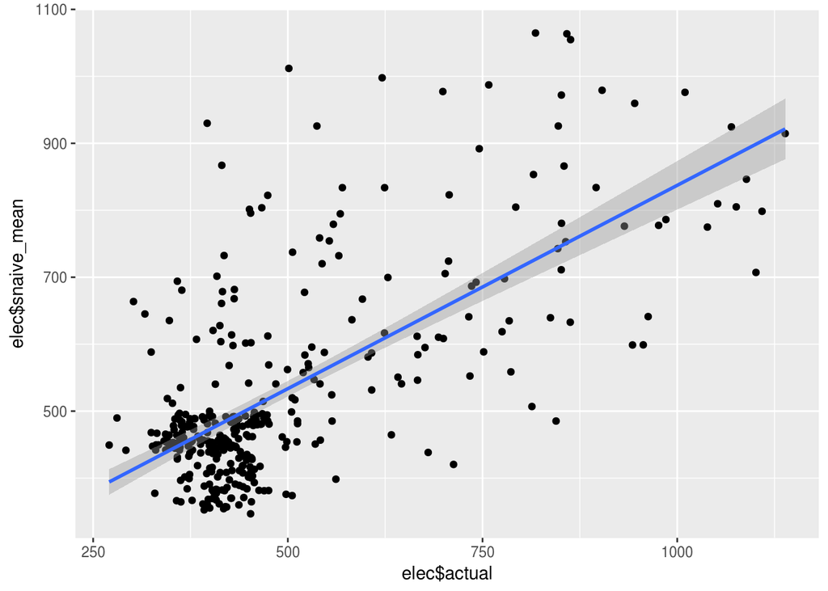

```r
ggplot(data=elec, aes(x=elec$actual,y=elec$snaive_mean)) +
    geom_point() +
    geom_smooth(method='lm')
```

```r
cor.test(elec$actual, elec$snaive_mean, method = "pearson", conf.level = 0.95)
```

```
##
##  Pearson's product-moment correlation
##
## data:  elec$actual and elec$snaive_mean
## t = 17.578, df = 363, p-value < 2.2e-16
## alternative hypothesis: true correlation is not equal to 0
## 95 percent confidence interval:
##  0.6184896 0.7299322
## sample estimates:
##       cor
## 0.6780894
```

```r
summary(lm(actual~ aa_mean,data=elec))
```

```
##
## Call:
## lm(formula = actual ~ aa_mean, data = elec)
##
## Residuals:
##     Min      1Q  Median      3Q     Max
## -400.72  -72.17  -11.94   49.88  472.59
##
## Coefficients:
##              Estimate Std. Error t value Pr(>|t|)
## (Intercept) 119.41378   22.34537   5.344 1.61e-07 ***
## aa_mean       0.75690    0.04306  17.579  < 2e-16 ***
## ---
## Signif. codes:  0 '***' 0.001 '**' 0.01 '*' 0.05 '.' 0.1 ' ' 1
##
## Residual standard error: 126.2 on 363 degrees of freedom
## Multiple R-squared:  0.4598, Adjusted R-squared:  0.4583
## F-statistic:   309 on 1 and 363 DF,  p-value: < 2.2e-16
```

The lm model summary shows an adj-R2 of 0.45 and F-statistic of 309. These are both an indication that the linear regression fit is poor between the actual and predicted results.